RESEARCH ARTICLE

Therapeutic targeting of STAT3 pathways in

pancreatic adenocarcinoma: A systematic

review of clinical and preclinical literature

**Sarah Peisl****ID**<sup>**1**</sup>**, Claudia Mellenthin****ID**<sup>**1**</sup>**, Lucie Vignot**<sup>**2**</sup>**, Carmen Gonelle-Gispert****ID**<sup>**3**</sup>**,**

**Leo Bu¨hler**<sup>**1**</sup>**, Bernhard Egger**<sup>**1,4**</sup>*

**1** Department of Surgery, HFR Fribourg, Fribourg, Switzerland, **2** Department of Oncology, HFR Fribourg,

Fribourg, Switzerland, **3** Surgical Research Unit, Faculty of Science and Medicine, University of Fribourg,

Fribourg, Switzerland, **4** Faculty of Science and Medicine, University of Fribourg, Fribourg, Switzerland

* bernhard-egger@bluewin.ch

Abstract

**Background/Objectives**

Pancreatic ductal adenocarcinoma is a highly lethal disease with increasing incidence. Due

to high resistance, chemo/radiotherapy has limited success in pancreatic cancer and only

marginally prolongs patient survival. Therefore, novel biomarkers and therapeutic targets

are needed. In the present review, we performed a comprehensive summary of therapeutic

approaches targeting the GP130/JAK/STAT3 pathway.

**Methods**

We systematically reviewed the PubMed and Embase databases for preclinical and clinical

studies, from inception to October 4, 2020, on drugs targeting the GP130/JAK/STAT3 path-

way. Bias assessments and qualitative analyses were performed.

**Results**

Twenty-five preclinical and nine clinical trials were included in the review. All preclinical stud-

ies reported a favorable outcome in terms of pancreatic ductal adenocarcinoma progres-

sion. Futhermore, drugs targeting the GP130/JAK/STAT3 pathway were shown to be

efficient chemosensitizers. However, high publication bias was assumed. In the clinical set-

ting, bazedoxifene and itacitinib improved patient outcomes.

**Conclusion**

Preclinical studies strongly suggest significant efficacy of drugs targeting GP130/JAK/

STAT3 in the treatment of pancreatic ductal adenocarcinoma and that these molecules are

effective chemosensitizers. Though only a few trials have shown the efficacy in a clinical set-

ting, the STAT3 pathway remains a promising drug target for future treatment of pancreatic

ductal adenocarcinoma and may help overcome chemotherapy resistance.

PLOS ONE

PLOS ONE | https://doi.org/10.1371/journal.pone.0252397

June 17, 2021

1 / 17

OPEN ACCESS

**Citation:** Peisl S, Mellenthin C, Vignot L, Gonelle-

Gispert C, Bu¨hler L, Egger B (2021) Therapeutic

targeting of STAT3 pathways in pancreatic

adenocarcinoma: A systematic review of clinical

and preclinical literature. PLoS ONE 16(6):

e0252397. https://doi.org/10.1371/journal.

pone.0252397

**Editor:** Gautam Sethi, National University

Singapore Yong Loo Lin School of Medicine,

SINGAPORE

**Received:** March 12, 2021

**Accepted:** May 14, 2021

**Published:** June 17, 2021

**Copyright:** © 2021 Peisl et al. This is an open

access article distributed under the terms of the

Creative Commons Attribution License, which

permits unrestricted use, distribution, and

reproduction in any medium, provided the original

author and source are credited.

**Data Availability Statement:** All relevant data are

within the paper and its Supporting information

files.

**Funding:** The author(s) received no specific

funding for this work.

**Competing interests:** The authors have declared

that no competing interests exist.

**Introduction**

Pancreatic ductal adenocarcinoma (PDAC) is a highly lethal disease with increasing incidence.

In most cases, pancreatic cancer presents at an advanced stage, with only 20% of all cases

undergoing surgical resection. In terms of prognostic outcomes for patients, pancreatic adeno-

carcinoma ranks last, with an overall 5-year survival rate of 2–9% [1, 2]. Even though the man-

agement of pancreatic adenocarcinoma is evolving with the introduction of novel surgical

techniques and medical therapies, only minor improvements in outcomes have been achieved.

Due to high resistance, chemotherapy and radiotherapy have limited success in metastatic

PDAC and only marginally prolong patient survival [3]. Current treatment options for meta-

static PDAC are modified FOLFIRINOX/FOLFIRINOX or nab-paclitaxel and gemcitabine in

patients with good performance status, and gemcitabine with or without a second agent for

those with poor performance status [4]. Most recently, trials studying the update of immuno-

therapy in PDAC were negative except in a subgroup of adenocarcinoma with microsatellite

instability [5].

Considering the lack of effective treatment, the identification of novel biomarkers and ther-

apeutic targets is fundamental to developing new treatment strategies and improving clinical

outcomes. Recent studies suggest that signaling pathways involving STAT3 play a key role in

tumorigenesis, progression and drug resistance in several human malignancies such as leuke-

mia, lymphomas as well as solid tumors such as hepatocelullar carcinoma, esophageal, lung,

prostate, bladder and breast cancer [6, 7]. Animal models of PDAC have shown that STAT3 is

an important regulator of stem cell self-renewal and cancer cell survival [8, 9]. Upregulation of

STAT3 has been shown to promote the development of PDAC from pancreatic intraepithelial

neoplasia [10, 11], as well as pro-metastatic niche formation in the liver [12]. Furthermore,

STAT3 has been shown to mediate resistance to chemotherapy and to be associated with

adverse outcomes following resection of PDAC with curative intent [13–15].

As illustrated in Fig 1, IL-6-type cytokines (IL-6, IL-10, IL-11, Leukemia inhibitory factor

(LIF), Cardiotrophin-1 (CT-1), Oncostatin-M (OSM), Ciliary neurotrophic factor (CNTF)),

bind glycoprotein-130 (GP130) and activate janus kinase (JAK), which in turn phosphorylates

STAT3, among other signaling mediators in PDAC tumor cells as well as cells of tumor micro-

environment (TME) [16]. TME in PDAC is a complex system which consists, along with

extensive stromal networks, of different cell components such as pancreatic stellate cells

(PSCs), cancer associated fibroblasts (CAFs), tumor associated macrophages (TAMs), mast

cells, regulatory T-cells and myeloid derived suppressor cells (MDSCs), synergizing to support

tumor progression, immune evasion and metastatic spreading. Interactions between different

cells within the TME are mediated through signaling molecules such as STAT3 activation via

IL-6-type cytokines. For instance, PDAC tumor cells can stimulate immune cells to secrete IL-

6-type cytokines, supporting the development of immunosuppressive TAMs and MDSCs as

well as the activation of PSCs and CAFs, which in turn induce the secretion of inflammatory

cytokines through positive feedback loops [11, 17–22]. Thus, STAT3 activation drives immune

enhanced transcription of downstream target genes, which promote angiogenesis, invasion,

and epithelial-mesenchymal transition (EMT) [23].

Accordingly, pathways involving STAT3 appear to be promising drug targets for the treat-

ment of PDAC. In particular, IL-6 has been shown to be a potentially efficient therapeutic

approach for overcoming chemotherapy resistance. The purpose of this study was to provide a

comprehensive summary of therapeutic approaches targeting the GP130/JAK/STAT3 pathway

in pancreatic adenocarcinoma through a systematic qualitative review of the literature.

PLOS ONE

Targeting STAT3 in pancreatic cancer

PLOS ONE | https://doi.org/10.1371/journal.pone.0252397

June 17, 2021

2 / 17

**Methods**

This systematic review was performed in accordance with the Preferred Reporting Items for

Systematic Reviews and Meta-Analyses (PRISMA) [24]. Studies were identified by searching

PubMed using the following search terms:

(carcinoma, pancreatic ductal[MeSH Terms]) AND (interleukin-6[MeSH Terms])

(carcinoma, pancreatic ductal[MeSH Terms]) AND (jak 2 protein tyrosine kinase[MeSH

Terms])

(carcinoma, pancreatic ductal[MeSH Terms]) AND (jak 1 protein tyrosine kinase[MeSH

Terms])

(carcinoma, pancreatic ductal[Mesh]) AND (stat3 transcription factor[MeSH Terms])

(carcinoma, pancreatic ductal[MeSH Terms]) AND (gp130, cytokine receptor[MeSH Terms])

Embase was searched using the following search query:

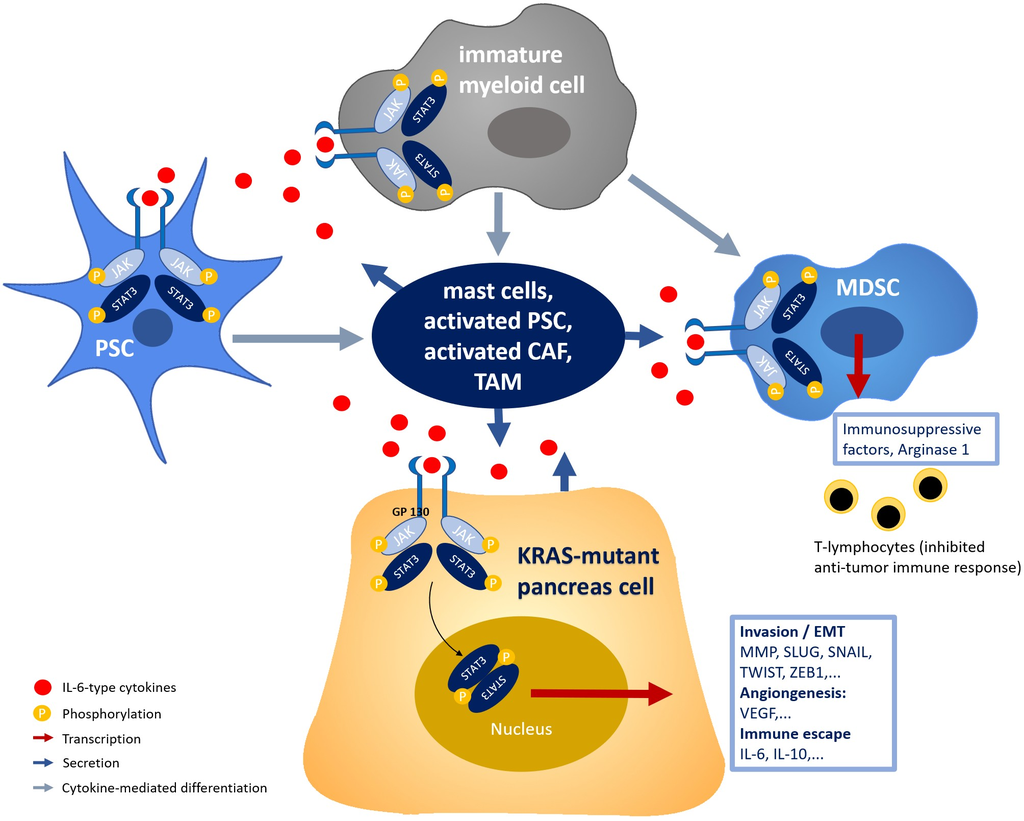

**Fig 1. Schematic presentation of IL-6/JAK/STAT3 pathway in pancreatic cancer cells and tumor microenvironment.** (PSC: pancreatic stellate cell,

CAF: cancer associated fibroblast, TAM: tumor associated macrophages, MDSC: myeloid derived suppressor cells).

https://doi.org/10.1371/journal.pone.0252397.g001

PLOS ONE

Targeting STAT3 in pancreatic cancer

PLOS ONE | https://doi.org/10.1371/journal.pone.0252397

June 17, 2021

3 / 17

(‘pancreas adenocarcinoma’/exp OR ‘adenocarcinoma, pancreas’ OR ‘pancreatic adenocarci-

noma’ OR ‘pancreatic ductal adenocarcinoma’) AND (‘stat3 protein’/exp OR ‘stat3 protein’

OR ‘stat3 transcription factor’ OR ‘protein stat3’ OR ‘signal transducer and activator of

transcription 3’ OR ‘stat3’ OR ‘transcription factor stat3’)

(‘pancreas adenocarcinoma’/exp AND ‘interleukin 6’/exp, filter for articles)

(‘pancreas cancer’/exp AND ‘janus kinase 2’/exp, filter for articles)

(‘janus kinase 1’/exp AND ‘pancreas cancer’/exp, filter for articles)

(‘gp130’/exp AND ‘pancreas cancer’/exp, filter for articles)

The electronic search was supplemented by a manual search of the reference lists of relevant

articles to identify any studies that may have been missed in the database searches. The original

database search was performed on May 5, 2020. The electronic search was updated on October

4, 2020.

Inclusion criteria were defined as all trials studying the pharmacological targeting of the

GP130-related cytokine/JAK/STAT3 pathway in pancreatic cancer, including studies on ani-

mal models or cell cultures. Only studies with an English abstract were included. Reviews,

comments, and conference or meeting abstracts were excluded from the analysis. No restric-

tions on publication date or publication status were imposed.

After exclusion of duplicates, records identified from the literature search were screened for

eligibility independently by the two main authors using the title and abstract in an unblinded

manner. Disagreements between the reviewers were resolved by consensus. The full-text of

articles meeting the inclusion criteria was assessed by the two main authors and reevaluated

for the inclusion criteria. Disagreements were, again, resolved by consensus.

We extracted data using a previously prepared extraction form. The information from each

included study on the study design, characteristics of analyzed subjects or trial participants,

characteristics of the pharmacological agent studied, type of outcome measures, and outcomes

was tabulated. On this basis, we performed a qualitative data synthesis.

We performed a quality assessment of clinical trials according to the ROB tool, which was

adapted to match non-randomized clinical trials [25]. For preclinical studies, we used the SYR-

CLE’s risk of bias tool, which was adapted to match *in vivo* and *in vitro* studies [26]. Results

were displayed in an analogous fashion as suggested by Higgins et al for systematic reviews of

interventions [25]. Bias assessment was conducted for every study by two independent asses-

sors and disagreements resolved by consensus.

Due to the nature of this study, approval from the local Ethics Committee was not required.

**Results**

**Study selection**

Our search identified 756 records through the database searches (Embase, Pubmed) and the

manual search of the reference lists of relevant articles. Initial screening excluded 689 records,

including 145 duplicates. The remaining 67 articles were assessed based on the full text, 29 of

which were found to be ineligible due to absence of a tested pharmacological substance or the

absence of GP130-related cytokine/JAK/STAT3 pathway targeting.

A summary of the study selection process is provided in Fig 2. Ultimately, 38 studies were

included in the review, including 4 ongoing trials. All included studies were published in

English and no unpublished data were included. No other studies were identified through the

electronic search update on October 4, 2020.

PLOS ONE

Targeting STAT3 in pancreatic cancer

PLOS ONE | https://doi.org/10.1371/journal.pone.0252397

June 17, 2021

4 / 17

**Bias assessment**

Table 1 shows the risk of bias assessment for the preclinical studies. Preclinical studies had

strong limitations to rigorous bias assessment because few provided sufficient details regarding

selection and performance bias. Study protocols were not published beforehand, so a compari-

son between intended interventions and published interventions was not possible. In animal

trials, few studies explicitly stated a randomization process for treatment groups, and treat-

ment results were often assessed manually with semi-quantitative methods. This lack of

reporting makes it difficult to accurately determine the risk of bias of the preclinical studies.

However, more details were available on the risk of attrition bias, reporting bias, and other

bias.

The quality assessment of the included clinical trials is provided in Table 2. The overall

quality of the studies was good, with only one study presenting high risk of selection bias.

**Preclinical studies**

As summarized in Table 3, 25 of the included studies were preclinical trials testing 20 sub-

stances targeting the GP130/JAK/STAT3-pathway. Twenty-four studies performed *in vitro*

experiments using human pancreatic cancer cells [17, 27–32, 34–36, 38–41, 43–47, 49, 50, 60,

61]. *In vivo* experiments were performed in 17 studies using mouse xenograft tumor models

(n = 14) [28, 31, 34, 35, 38, 40–42, 44, 45, 48–50, 60], chicken chorio-allantoic membrane

xenograft tumor models (n = 1) [32], or KPC mice (n = 2) [33, 45]. All studies reported favor-

able outcomes in terms of pancreatic cancer cell viability, proliferation, migration, colony for-

mation ability, apoptosis, or effects on downstream target genes, as well as tumor growth,

tumor volume, or weight in *in vivo* models. Eight studies analyzed the combinational effect of

the investigated drug with chemotherapy (i.e., gemcitabine, paclitaxel, 5-fluorouracil, and oxa-

liplatin) [31, 33, 38, 40, 41, 45, 49, 60]. In all studies, the inhibitory effect on pancreatic cancer

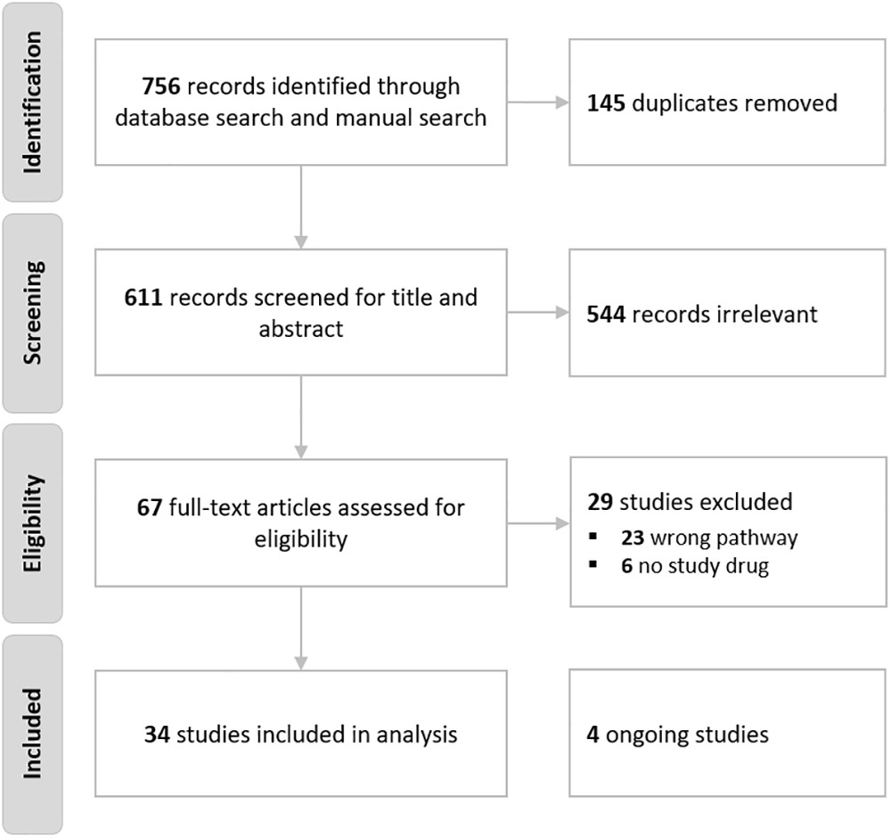

**Fig 2. PRISMA flow chart of included studies.**

https://doi.org/10.1371/journal.pone.0252397.g002

PLOS ONE

Targeting STAT3 in pancreatic cancer

PLOS ONE | https://doi.org/10.1371/journal.pone.0252397

June 17, 2021

5 / 17

**Table 1. Bias assessment of preclinical studies.**

**Reference**

**Chen**

**2019**

**Edderkaoui**

**2013**

**Fu**

**2018**

**Ge**

**2015**

**Goumas**

**2015**

**Lin**

**2010**

**Long**

**2017**

**Palagani**

**2014**

**Sahu**

**2017**

**Sun**

**2009**

**Thoennissen**

**2009**

**Wu**

**2016**

**Zhang**

**2018**

**Nagaraju**

**2016**

**Nagaraju**

**2019**

**Chen**

**2016**

**Lu**

**2019**

**Liu**

**2011**

**Huang**

**2016**

**Luo**

**2019**

**Kim**

**2016**

**Venkatasubbara**

**2005**

**Lu**

**2017**

**Liu**

**2019**

**Song**

**2018**

**[****27****]**

**[****28****]**

**[****29****]**

**[****30****]**

**[****31****]**

**[****32****]**

**[****33****]**

**[****34****]**

**[****35****]**

**[****36****]**

**[****37****]**

**[****38****]**

**[****39****]**

**[****40****]**

**[****41****]**

**[****17****]**

**[****42****]**

**[****43****]**

**[****44****]**

**[****45****]**

**[****46****]**

**[****47****]**

**[****48****]**

**[****49****]**

**[****50****]**

T

B

T

T

B

B

V

B

B

T

B

B

T

B

B

T

V

T

B

B

T

T

T

B

B

1) Selection

//

O

//

//

O

O

O

X

O

//

O

X

//

//

O

//

X

//

X

O

//

//

//

O

O

2)

Performance

//

X

//

//

X

X

X

X

X

//

X

X

//

X

X

//

//

//

X

X

//

//

//

X

X

3) Detection

X

X

O

O

//

//

//

//

//

O

X

//

O

//

O

//

//

X

X

//

O

O

O

O

//

4) Reporting

O

O

O

O

O

O

O

O

O

O

O

O

O

O

O

O

O

O

O

O

O

O

O

O

O

5) Other

O

O

O

O

O

O

O

O

O

O

O

O

O

O

O

O

O

O

O

O

O

O

O

O

O

1) Was the allocation sequence adequately generated, applied, and concealed? Were the groups similar at baseline or were they adjusted for confounders?

2) Were the caregivers and/or investigators blinded from knowledge of which intervention each animal received during the experiment?

3) Were animals/cell cultures selected at random for outcome assessment? Was the outcome assessor blinded? Was a computed/automatic tool used?

4) Are reports of the study free of selective outcome reporting?

5) Was the study apparently free of other problems that could result in high risk of bias?

V: In vivo study T: in vitro study B: in vivo and in vitro

O Meets criteria (low risk of biais) // Some concerns (unclear risk of bias, insufficient reporting) X Does not meet criteria (high risk of bias)

https://doi.org/10.1371/journal.pone.0252397.t001

PLOS ONE

Targeting STAT3 in pancreatic cancer

PLOS ONE | https://doi.org/10.1371/journal.pone.0252397

June 17, 2021

6 / 17

**Clinical studies**

As summarized in Table 4, nine of the studies were clinical trials including 880 individuals and

assessing 5 drugs. One study performed a retrospective analysis of bazedoxifene, an inhibitor

of the IL-6/IL-6R/GP130 complex, in patients with pancreatic (n = 5) or gastric adenocarci-

noma (n = 2), showing biological tumor marker reduction in 80% and disease regression on

PET-CT in 60% of cases [51]. Icatinib, a selective JAK1 inhibitor, was tested in combination

with nab-paclitaxel and gemcitabine, showing a synergistic effect with an overall response rate

of 24% with an acceptable safety profile in a phase 1b/2 study [52]. However, this study was ter-

minated early due to negative phase 3 results for JAK1/2 inhibitor ruxolitinib [55]. Momeloti-

nib, a JAK1/2 inhibitor, resulted in a partial response in 28% of patients with previously

untreated metastatic PDAC (n = 25) in a phase 1 study. However, no significant difference was

reported from treatment with paclitaxel and gemcitabine [53]. Ruxolitinib, a JAK1/2 inhibitor,

has been investigated in phase 1b, 2, and 3 clinical trials in combination with capecitabine,

gemcitabine, and paclitaxel, revealing no significant difference in overall survival or progres-

sion-free survival in patients with PDAC [54–56]. Finally, phase 2 and 3 studies have been per-

formed assessing tipifarnib, an inhibitor of STAT3 phosphorylation that showed no single-

agent antitumor activity and no difference in overall survival in combination with gemcitabine

**Table 2. Bias assessment of the clinical studies.**

**Reference**

**Burkhardt**

**2019**

**Beatty**

**2019**

**Ng**

**2019**

**Bauer**

**2018**

**Hurwitz**

**2018**

**Hurwitz**

**2015**

**Eckhardt**

**2009**

**Macdonald**

**2005**

**Cohen**

**2003**

**[****51****]**

**[****52****]**

**[****53****]**

**[****54****]**

**[****55****]**

**[****56****]**

**[****57****]**

**[****58****]**

**[****59****]**

Design Phase

R

P

P

P

P

P

P

P

P

Ib/II

I

Ib

III

II

III

II

II

1) Selection

process

X

//

//

//

O

O

O

O

O

2) Deviation

from intended

intervention

O

O

O

O

O

O

O

O

O

3) Missing

outcome data

O

O

O

O

O

O

O

O

O

4)

Measurement

of the outcome

//

O

O

O

O

O

O

O

O

5) Selection of

the reported

result

O

O

O

O

O

O

O

O

O

6) Overall

//

O

O

O

O

O

O

O

O

1) Does the patient(s) represent(s) the whole experience of the investigator? Is the selection method clear? Was the

allocation sequence random?

2) Did the investigator deviate from intended interventions? Were investigators/study participants blinded?

3) Is there evidence that the result was not biased by missing outcome data? Were incomplete outcome data

adequately addressed?

4) Was the method of measuring the outcome (in)appropriate? Could measurement or ascertainment of the outcome

have differed between intervention groups?

5) Were the data that produced this result analyzed in accordance with a pre-specified analysis plan?

6) Was the study apparently free of other problems that could result in high risk of bias?

R: retrospective P: prospective

O Meets criteria (low risk of bias) // Some concerns (unclear risk of bias, insufficient reporting) X Does not meet

criteria (high risk of bias)

https://doi.org/10.1371/journal.pone.0252397.t002

PLOS ONE

Targeting STAT3 in pancreatic cancer

PLOS ONE | https://doi.org/10.1371/journal.pone.0252397

June 17, 2021

7 / 17

**Table 3. Characteristics of the included preclinical studies.**

**Reference**

**Study**

**design**

**Drug**

**Mechanism of action**

**Subject**

**Number**

**Outcome**

Zhang 2018

[39]

In vitro

AG490 (Tyrphostin

B42)

JAK2/STAT3 inhibition

HPCC

-

# cell viability, # STAT3 overexpression and

phosphorylation, downregulation of target

genes

Palagani 2014

[34]

In vitro

AG490

JAK2/STAT3 inhibition

HPCC

-

In vitro: # cell proliferation, " apoptosis

In vivo

+ GSI IX

+ Notch (Hes1)

inhibition

Mouse XTM

20

In vivo: # cell proliferation, # tumor growth

Wu 2016

[38]

In vitro

Bazedoxifene

Inhibitor of IL-6/IL-6R/

GP130 complex

HPCC

-

In vitro: # STAT3 phosphorylation,

downregulation of target genes, # cell migration

In vivo

+ Pac

Mouse XTM

8

In vivo: # tumor growth, enhanced effect with

Pac

+ Gem

No significant toxicity

Fu 2018

[29]

In vitro

Bazedoxifene

Inhibitor of IL-6/IL-6R/

GP130 complex

HPCC

-

# cell viability, # cell migration, # colony

formation Enhanced effect with combinational

therapy

+ reparixine

+ SCH527123

Chen 2019

[27]

In vitro

Bazedoxifene

Inhibitor of IL-6/IL-6R/

GP130 complex

HPCC

-

# cell viability, # cell proliferation, # colony

formation

Ge 2015

[30]

In vitro

Cryptotanshinone

STAT3 inhibition

HPCC

-

" apoptosis, downregulation of target genes

Thoennissen 2009

[37]

In vitro

Cucurbitacin B

Inhibition of

phosphorylation of JAK2

and STAT3

HPCC

-

In vitro: # cell proliferation, " apoptosis,

enhanced effect with combinational therapy

In vivo

+ Gem

Mouse XTM

5

In vivo: # tumor volume, # tumor weight

Sun 2009

[62]

In vitro

Cucurbitacin E

Inhibition of STAT3

phosphorylation

HPCC

-

# cell proliferation, " apoptosis

Edderkaoui 2013

[28]

In vitro

Ellagic acid

1) Inhibition of STAT3

phosphorylation

HPCC

-

# cell proliferation, " apoptosis by embelin

In vivo

Embelin

2) inhibition of NF-kB

Mouse XTM

24

Enhanced effect with combinational therapy

Lin 2010

[32]

In vitro

FLLL31

Selective inhibition of

JAK2/STAT3(SH2)

HPCC

-

In vitro: # STAT3 phosphorylation,

downregulation of target genes, " apoptosis

In vivo

FLLL 32

Chorio-allantoic

membrane XTM

-

In vivo: # tumor volume, # neo-angiogenesis

Nagaraju 2016

[40]

In vitro

Ganetispib

HSP90 und JAK2

inhibition

HPCC

-

In vitro: # cell proliferation

In vivo

+ Gem/Pac

Mouse XTM

35

In vivo: # tumor growth, enhanced effect with

combinational therapy

+ 5-FU/Ox

Nagaraju 2019

[41]

In vitro

Ganetispib

HSP90 und JAK2

inhibition

HPCC

-

In vitro: # cell proliferation, # VEGF

In vivo

+ 5-FU

Mouse XTM

16

In vivo: enhanced effect with combinational

therapy, no significant toxicity

Lu 2019

[42]

In vitro

IL-9 antibody

Inhibition of IL-9

HPCC

-

In vitro: # STAT3 phosphorylation, # VEGF

In vivo

Mouse XTM

48

In vivo: # tumor weight, " survival

Chen 2016

[17]

In vitro

Interleukin 32α

Inhibition of JAK2/

STAT3

HPCC

-

Downregulation of target genes

Liu 2011

[43]

In vitro

LLL12

Blocking of IL-

6-induced STAT3

phosphorylation

HPCC

-

# STAT3 phosphorylation, #cell viability

Huang 2016

[44]

In vitro

LTP-1

STAT3 inhibitor

HPCC

-

In vitro: # cell proliferation, # cell viability, "

apoptosis

In vivo

Mouse XTM

40

In vivo: # tumor growth

Kim 2016

[46]

In vitro

Morusin

STAT3 inhibitor

HPCC

-

#STAT3 phosphorylation, downregulation of

target genes, " apoptosis

(*Continued*)

PLOS ONE

Targeting STAT3 in pancreatic cancer

PLOS ONE | https://doi.org/10.1371/journal.pone.0252397

June 17, 2021

8 / 17

[57–59]. Four ongoing clinical trials were found, involving tocilizumab, an anti-IL6Rα anti-

body with favorable results in preclinical studies [31, 33], and napabucasin, a STAT3 inhibitor

that is also under investigation in colorectal cancer [63].

**Discussion**

The present systematic review of 25 preclinical studies and 9 clinical trials revealed a good

overall effect of the investigated drugs targeting the GP130/JAK/STAT3 pathway in the treat-

ment of PDAC. Table 5 summarizes the outcome and the state of research for each assessed

drug. Favorable outcomes have been reported for all 20 drugs investigated in a preclinical set-

ting. Even though these substances appear promising in the treatment of PDAC, only five of

these drugs have been investigated in clinical trials. Favorable outcomes and acceptable toxicity

profiles have been found in studies investigating bazedoxifene and itacitinib [51, 52]. Notably,

**Table 3.** (Continued)

**Reference**

**Study**

**design**

**Drug**

**Mechanism of action**

**Subject**

**Number**

**Outcome**

Luo 2019

[45]

In vitro

Phospho-valproic acid

(MDC-1112)

HPCC

-

In vitro: # cell proliferation, # colony formation,

In vivo

+ Gem

+ 5-FU

Mouse XTM

16

# invasion, " apoptosis with combinational

therapy

+ abraxane

KPC mice

30

In vivo: # STAT3 phosphorylation,

downregulation of target genes, # tumor growth

with Gem

Sahu 2017

[35]

In vitro

1) Ponatinib

1) Multi-receptor

tyrosine kinase inhibitor

HPCC

-

In vitro: # cell proliferation

In vivo

2) Cobemetinib

2) MEK inhibitor

Mouse XTM

80

In vivo: -# tumor growth, " apoptosis with

combinational therapy, safety issues (weight

loss)

Lu 2017

[48]

In vitro

Ruxolitinib

JAK1/2 inhibitor

HPCC

-

In vitro: # T cell proliferation

In vivo

Mouse XTM

30

In vivo: # STAT3 phosphorylation, " cytotoxic

T-lymphocyte infiltration and activation

Liu 2019

[49]

In vitro

S-Adenosyl-

methionine (SAM)

Inhibition of JAK2/

STAT3

HPCC

-

In vitro: # cell proliferation, " apoptosis, #

invasion

In vivo

+ Gem

Mouse XTM

24

In vivo: # tumor weight, # tumor volume,

enhanced effect with combinational therapy

Song 2018

[50]

In vitro

SZC015 (oleanolic

acid derivative)

Suppression of NFκB

and JAK2/STAT3

HPCC

-

In vitro: # cell viability

In vivo

Mouse XTM

15

In vivo: # JAK2/STAT3 signaling, " apoptosis

Venkatasubbarao

2005

[47]

In vitro

Tipifarnib (R1115777)

Inhibition of STAT3

phosphorylation

HPCC

-

# STAT3 phosphorylation

Goumas 2015

[31]

In vitro

Tocilizumab

1) Anti-IL6Rα,

humanized monoclonal

antibody

HPCC

-

In vitro: # STAT3 phosphorylation

In vivo

2) sgp130Fc

2) GP130 inhibitor

Mouse XTM

40

In vivo: # tumor growth, # neoangiogenesis, no

enhanced effect with Gem, # tumor recurrence

and metastasis as adjuvant treatment after

surgery

+ Gem

+ surgery

Long 2017

[33]

In vivo

Tocilizumab

Anti-IL6Rα, humanized

monoclonal antibody

KPC mice

-

# STAT3 phosphorylation, # cell proliferation,

+ Gem

" apoptosis, enhanced effect with Gem

HPCC: human pancreatic cancer cell, PDAC: pancreatic ductal adenocarcinoma, XTM: xenograft tumor model, Ox: oxaliplatin, Gem: gemcitabine, Pac: paclitaxel,

5-FU: 5-fluorouracil,—indicates no data available

https://doi.org/10.1371/journal.pone.0252397.t003

PLOS ONE

Targeting STAT3 in pancreatic cancer

PLOS ONE | https://doi.org/10.1371/journal.pone.0252397

June 17, 2021

9 / 17

bazedoxifene is already approved for the treatment of osteoporosis [64], and itacitinib has

been shown to have great potential in recent clinical trials studying the treatment of connective

tissue diseases and graft-versus-host disease, among others [65–67].

Even though the PDAC tumor micro-environment (TME) has been shown to be a promis-

ing target for improving PDAC treatment, none of the included studies in this systematic

review examined the influence of the analyzed substances on stromal or immune cells.

**Table 4. Characteristics of included clinical studies.**

**Reference**

**Study design**

**Drug**

**Mechanism of action**

**Subject**

**Number**

**Outcome**

Burkhardt

2019

[51]

Retrospective

Bazedoxifene

Inhibitor of IL-6/IL-

6R/GP130 complex

PDAC

5

Tumor marker reduction of 80%

Gastric adenocarcinoma

2

Stability of disease on CT in 60%

Regression on PET-CT in 60%

Beatty 2019

[52]

Phase 1b/2 dose-

finding study

Itacitinib

Selective

JAK1-inhibition

Advanced PDAC

46

Terminated early due to futility of

JANUS study [55]

+ paclitaxel

Other advanced solid

tumors

9

Acceptable safety profile

+ gemcitabine

Overall response rate: 24%

Ng 2019

[53]

Phase 1 dose-

escalation study

Momelotinib

JAK1/2 inhibitor

Untreated metastatic PDAC

25

No significant increase in PFS or OS

+ paclitaxel

MTD: not reached

+ gemcitabine

AE: fatigue (80%), nausea (76%),

anemia (68%).

Partial response in 28%, stable disease

in 52%

Hurwitz

2015

[56]

Randomized

Phase 2

Ruxolitinib

JAK1/2 inhibitor

Metastatic PDAC after

treatment failure with

gemcitabine

127

No significant increase in PFS

+ capecitabine

Significant increase in OS in patients

with inflammation compared to

placebo (p = 0.011)

Grade 3 anemia more frequent

compared to placebo

Bauer 2018

[54]

Phase 1b dose-

finding study

Ruxolitinib

JAK1/2 inhibitor

Untreated advanced PDAC

34

Terminated early due to disease

progression in 81%

+ gemcitabine

Other advanced solid

tumors

8

Overall response rate in PDAC: 23.5%

+ paclitaxel

Acceptable toxicity profile

Hurwitz

2018

[55]

Randomized

Phase 3 (JANUS)

Ruxolitinib

JAK1/2 inhibitor

Advanced PDAC

307

Terminated early due to futility

+ capecitabine

No significant difference in PFS or OS

Acceptable toxicity profile

Eckhardt

2009

[57]

Randomized

Phase 3

Tipifarnib

(R115777)

Inhibition of STAT3

phosphorylation

Advanced PDAC

244

No significant difference in survival

+ gemcitabine

Acceptable toxicity profile

Most common AE: neutropenia,

thrombocytopenia

Macdonald

2005

[58]

Randomized

Phase 2

Tipifarnib

(R115777)

Inhibition of STAT3

phosphorylation

Untreated advanced PDAC

53

6-month survival rate: 19%

Median time to treatment failure: 1.4

months

No single-agent antitumor activity

Cohen 2003

[59]

Randomized

Phase 2

Tipifarnib

(R115777)

Inhibition of STAT3

phosphorylation

Untreated advanced PDAC

20

100% progression at 6 months

6-month survival rate: 25%

No single-agent antitumor activity

PFS: progression-free survival, OS: overall survival, MTD: maximum tolerable dose, AE: adverse event, PDAC: pancreatic ductal adenocarcinoma,—indicates no data

available

https://doi.org/10.1371/journal.pone.0252397.t004

PLOS ONE

Targeting STAT3 in pancreatic cancer

PLOS ONE | https://doi.org/10.1371/journal.pone.0252397

June 17, 2021

10 / 17

**Table 5. Summary of findings by drug.**

**Drug**

**Mechanism of action**

**Outcome**

**State of research**

Bazedoxifene

Inhibitor of IL-6/IL-6R/

GP130 complex

Positive

Clinical study, retrospective

Synergism with paclitaxel

and gemcitabine

Ganetespib

HSP90/JAK2

Positive

Preclinical research

Synergism with

gemcitabine/paclitaxel and

5-fluorouracil/oxaliplatin

Ruxolitinib

JAK1/2 inhibitor

Negative in combination

with gemcitabine/paclitaxel

Phase 1b clinical trial

Negative in combination

with capecitabine

Phase 2+3 clinical trial

Tipifarnib (R1115777)

Inhibition of STAT3

phosphorylation

Negative as single agent

Phase 2 clinical trials

Negative in combination

with gemcitabine

Phase 3 clinical trial

Momelotinib

JAK1/2 inhibitor

Negative

Phase 1 clinical trial

Negative in combination

with gemcitabine and

paclitaxel

Itacitinib

Selective JAK-1

inhibition

Positive

Phase 2 clinical trial

AG490

JAK2 inhibitor

Positive

Preclinical research

Cryptotanshinone

STAT3 inhibition

Positive

Preclinical research

Cucurbitacin B

Inhibition of

phosphorylation of JAK2

and STAT3

Positive; synergism with

gemcitabine

Preclinical research

Cucurbitacin E

Inhibition of STAT3

phosphorylation

Positive

Preclinical research

Ellagic acid

Inhibition of STAT3

phosphorylation

Positive

Preclinical research

FLLL31/32

Selective JAK2/STAT3

(SH2) inhibition

Positive

Preclinical research

IL-32α

Inhibition of JAK2/

STAT3

Positive

Preclinical research

IL-9 antibody

IL-9 inhibition

Positive

Preclinical research

LLL12

Blocking of IL-6-induced

STAT3 phosphorylation

Positive

Preclinical research

LTP-1

STAT3 inhibitor

Positive

Preclinical research

Morusin

STAT3 inhibitor

Positive

Preclinical research

Phospho-valproic acid

(MDC-1112)

STAT3 inhibitor

Positive; synergism with

gemcitabine

Preclinical research

Ponatinib

Multi-receptor tyrosine

kinase inhibitor

Positive

Preclinical research

S-Adenosylmethionine

(SAM)

Inhibition of JAK2/

STAT3

Positive; synergism with

gemcitabine

Preclinical research

SZC015

Suppression of NFκB

and JAK2/STAT3

Positive

Preclinical research

Tocilizumab

Anti-IL6Rα, humanized

monoclonal antibody

Positive; synergism with

gemcitabine

Preclinical research

Ongoing clinical trials

(NCT04258150,

NCT02767557)

Napabucasin

STAT3 inhibitor

Ongoing

Ongoing phase 1 and 3

clinical trials (NCT02231723,

NCT02993731)

https://doi.org/10.1371/journal.pone.0252397.t005

PLOS ONE

Targeting STAT3 in pancreatic cancer

PLOS ONE | https://doi.org/10.1371/journal.pone.0252397

June 17, 2021

11 / 17

The TME plays an important role in tumorigenesis and chemoresistance by close interac-

tion with tumor cells. Furthermore, TME has been shown to be highly immunosuppressive,

promoting immune evasion, hence sustaining tumor progression [18–20]. Immunotherapy, so

far, has not demonstrated substantial clinical improvement as single agent in the treatment of

PDAC [5]. Therefore, strategies simultaneously targeting PDAC tumor cells as well as different

immune checkpoints might be needed. The interactions of PDAC tumor cells and different

cells within the TME such as CAFs, MDSCs, TAMs, are mediated through GP130/JAK/STAT3

pathway [11, 17–20, 68]. STAT3 inhibition might thus have consequences in shaping TME

towards anti-tumor phenotype by acting on both immune and tumor cells [18–20]. In combi-

nation with chemotherapeutic agents and immunotherapy, it might significantly increase ther-

apeutic efficacy in the treatment of PDAC.

Recent studies have shown the important role of the STAT3 pathway in tumorigensis, as

well as the STAT3-mediated resistance to chemotherapy in *in vivo* models of PDAC [8–15].

The results from the preclinical trials presented in this review confirmed the importance of the

GP130/JAK/STAT3 pathway in PDAC and its role as a possible drug target. Furthermore, sev-

eral of the studies showed a synergy between the investigational drug and chemotherapy, such

as gemcitabine, paclitaxel, 5-fluorouracil, and oxaliplatin [31, 33, 38, 40, 41, 45, 49, 53–55, 57,

60]. However, to the best of our knowledge, drugs targeting GP130/JAK/STAT3 have never

been studied as chemosensitizers in addition to the currently emerging FOLFIRINOX regimen

[4]. Even though some promising outcomes have been shown in clinical trials [51, 52], several

studies were terminated prematurely due to high progression rates and futility. This may

reflect the difficulty showing a significant benefit in patients presenting with PDAC, as it is

known to be a highly lethal disease that is often diagnosed at an advanced stage and has a poor

prognosis with an overall 5-year survival rate of 2–9% [1, 2].

The discrepancy between preclinical and clinical data may also result from the fact that, in

contrast to the preclinical studies, the clinical trials did not verify the activation of the STAT3

pathway in PDAC. The benefit of targeted GP130/JAK/STAT3 therapy may be increased by

selecting patients with previously known STAT3 pathway activation in PDAC cells.

The present systematic review included all preclinical and clinical trials of drugs targeting

the GP130/JAK/STAT3 pathway. Furthermore, we searched for ongoing, unpublished trials,

leading to a thorough analysis of the current state of research. However, because all published

preclinical studies reported a positive outcome, we suspect that several negative studies may

not have been published and concluded relevant publication bias, leading to an overestimation

of the effect of GP130/JAK/STAT3-targeting drugs in the treatment of PDAC in the preclinical

setting. Furthermore, the substantial heterogeneity among the preclinical and clinical studies

did not allow a quantitative analysis or measurement of the effect size.

**Conclusion**

Preclinical studies strongly suggest significant efficacy of drugs targeting GP130/JAK/STAT3 in

the treatment of PDAC and that these molecules are effective chemosensitizers, possibly through

simultaneous effect on tumor cells and TME. Though only a few trials have shown the efficacy

in a clinical setting, the GP130/JAK/STAT3 pathway remains a promising drug target for the

development of future treatments for PDAC and may help overcome chemotherapy resistance.

**Supporting information**

**S1 Checklist.**

(DOC)

PLOS ONE

Targeting STAT3 in pancreatic cancer

PLOS ONE | https://doi.org/10.1371/journal.pone.0252397

June 17, 2021

12 / 17

**Author Contributions**

**Conceptualization:** Sarah Peisl, Claudia Mellenthin, Lucie Vignot, Carmen Gonelle-Gispert,

Leo Bu¨hler, Bernhard Egger.

**Data curation:** Sarah Peisl, Claudia Mellenthin.

**Formal analysis:** Sarah Peisl, Claudia Mellenthin.

**Investigation:** Sarah Peisl.

**Methodology:** Sarah Peisl, Claudia Mellenthin.

**Project administration:** Sarah Peisl, Claudia Mellenthin.

**Supervision:** Leo Bu¨hler, Bernhard Egger.

**Validation:** Sarah Peisl, Claudia Mellenthin, Lucie Vignot, Carmen Gonelle-Gispert, Leo Bu¨h-

ler, Bernhard Egger.

**Visualization:** Sarah Peisl, Claudia Mellenthin.

**Writing – original draft:** Sarah Peisl, Claudia Mellenthin.

**Writing – review & editing:** Sarah Peisl, Claudia Mellenthin, Lucie Vignot, Carmen Gonelle-

Gispert, Leo Bu¨hler, Bernhard Egger.

**References**

**1.**

Yeo TP. Demographics, Epidemiology, and Inheritance of Pancreatic Ductal Adenocarcinoma. Semin

Oncol. 2015 Feb; 42(1):8–18. https://doi.org/10.1053/j.seminoncol.2014.12.002 PMID: 25726048

**2.**

Baugh KA, Tran Cao HS, van Buren G, Silberfein EJ, Hsu C, Chai C, et al. Understaging of clinical

stage I pancreatic cancer and the impact of multimodality therapy. Surgery. 2019 Feb; 165(2):307–14.

https://doi.org/10.1016/j.surg.2018.08.003 PMID: 30243481

**3.**

McGuigan A, Kelly P, Turkington RC, Jones C, Coleman HG, McCain RS. Pancreatic cancer: A review

of clinical diagnosis, epidemiology, treatment and outcomes. World J Gastroenterol. 2018 Nov 21; 24

(43):4846–61. https://doi.org/10.3748/wjg.v24.i43.4846 PMID: 30487695

**4.**

Singh RR, O’Reilly EM. New Treatment Strategies for Metastatic Pancreatic Ductal Adenocarcinoma.

Drugs. 2020 May 1; 80(7):647–69. https://doi.org/10.1007/s40265-020-01304-0 PMID: 32306207

**5.**

Schizas D, Charalampakis N, Kole C, Economopoulou P, Koustas E, Gkotsis E, et al. Immunotherapy

for pancreatic cancer: A 2020 update. Cancer Treat Rev. 2020 Jun; 86:102016. https://doi.org/10.1016/

j.ctrv.2020.102016 PMID: 32247999

**6.**

Lee JH, Mohan CD, Deivasigamani A, Jung YY, Rangappa S, Basappa S, et al. Brusatol suppresses

STAT3-driven metastasis by downregulating epithelial-mesenchymal transition in hepatocellular carci-

noma. J Adv Res. 2020 Nov; 26:83–94. https://doi.org/10.1016/j.jare.2020.07.004 PMID: 33133685

**7.**

Garg M, Shanmugam MK, Bhardwaj V, Goel A, Gupta R, Sharma A, et al. The pleiotropic role of tran-

scription factor STAT3 in oncogenesis and its targeting through natural products for cancer prevention

and therapy. Med Res Rev. 2020 Dec 1; https://doi.org/10.1002/med.21761 PMID: 33289118

**8.**

Corcoran RB, Contino G, Deshpande V, Tzatsos A, Conrad C, Benes CH, et al. STAT3 Plays a Critical

Role in KRAS-Induced Pancreatic Tumorigenesis. Cancer Res. 2011 Jul 15; 71(14):5020–9. https://doi.

org/10.1158/0008-5472.CAN-11-0908 PMID: 21586612

**9.**

O<sup>¨</sup>hlund D, Handly-Santana A, Biffi G, Elyada E, Almeida AS, Ponz-Sarvise M, et al. Distinct populations

of inflammatory fibroblasts and myofibroblasts in pancreatic cancer. J Exp Med. 2017; 214(3):579–96.

https://doi.org/10.1084/jem.20162024 PMID: 28232471

**10.**

Gruber R, Panayiotou R, Nye E, Spencer-Dene B, Stamp G, Behrens A. YAP1 and TAZ Control Pan-

creatic Cancer Initiation in Mice by Direct Up-regulation of JAK–STAT3 Signaling. Gastroenterology.

2016 Sep; 151(3):526–39. https://doi.org/10.1053/j.gastro.2016.05.006 PMID: 27215660

**11.**

Lesina M, Kurkowski MU, Ludes K, Rose-John S, Treiber M, Klo¨ppel G, et al. Stat3/Socs3 Activation by

IL-6 Transsignaling Promotes Progression of Pancreatic Intraepithelial Neoplasia and Development of

Pancreatic Cancer. Cancer Cell. 2011 Apr; 19(4):456–69. https://doi.org/10.1016/j.ccr.2011.03.009

PMID: 21481788

PLOS ONE

Targeting STAT3 in pancreatic cancer

PLOS ONE | https://doi.org/10.1371/journal.pone.0252397

June 17, 2021

13 / 17

**12.**

Lee JW, Stone ML, Porrett PM, Thomas SK, Komar CA, Li JH, et al. Hepatocytes direct the formation of

a pro-metastatic niche in the liver. Nature. 2019 Mar; 567(7747):249–52. https://doi.org/10.1038/

s41586-019-1004-y PMID: 30842658

**13.**

Tan F, Putoczki T, Stylli S, Luwor R. The Role of STAT3 Signaling in Mediating Tumor Resistance to

Cancer Therapy. Curr Drug Targets. 2014 Dec 16; 15(14):1341–53. https://doi.org/10.2174/

1389450115666141120104146 PMID: 25410411

**14.**

Denley SM, Jamieson NB, McCall P, Oien KA, Morton JP, Carter CR, et al. Activation of the IL-6R/Jak/

Stat Pathway is Associated with a Poor Outcome in Resected Pancreatic Ductal Adenocarcinoma. J

Gastrointest Surg. 2013 May; 17(5):887–98. https://doi.org/10.1007/s11605-013-2168-7 PMID:

23435739

**15.**

Xing H-B, Tong M-T, Wang J, Hu H, Zhai C-Y, Huang C-X, et al. Suppression of *IL-6* Gene by shRNA

Augments Gemcitabine Chemosensitization in Pancreatic Adenocarcinoma Cells. BioMed Res Int.

2018; 2018:1–10. https://doi.org/10.1155/2018/3195025 PMID: 29693005

**16.**

Xu S, Neamati N. Gp130: A promising drug target for cancer therapy. Expert Opin Ther Targets. 2013;

17(11):1303–28. https://doi.org/10.1517/14728222.2013.830105 PMID: 24099136

**17.**

Chen J, Wang S, Su J, Chu G, You H, Chen Z, et al. Interleukin-32α inactivates JAK2/STAT3 signaling

and reverses interleukin-6-induced epithelial-mesenchymal transition, invasion, and metastasis in pan-

creatic cancer cells. OncoTargets Ther. 2016; 9:4225–37.

**18.**

van Duijneveldt G, Griffin MDW, Putoczki TL. Emerging roles for the IL-6 family of cytokines in pancre-

atic cancer. Clin Sci. 2020 Aug 28; 134(16):2091–115. https://doi.org/10.1042/CS20191211 PMID:

32808663

**19.**

Weber R, Groth C, Lasser S, Arkhypov I, Petrova V, Altevogt P, et al. IL-6 as a major regulator of MDSC

activity and possible target for cancer immunotherapy. Cell Immunol. 2021 Jan; 359:104254. https://

doi.org/10.1016/j.cellimm.2020.104254 PMID: 33296753

**20.**

Trovato R, Fiore A, Sartori S, Canè S, Giugno R, Cascione L, et al. Immunosuppression by monocytic

myeloid-derived suppressor cells in patients with pancreatic ductal carcinoma is orchestrated by

STAT3. J Immunother Cancer. 2019 Dec; 7(1):255. https://doi.org/10.1186/s40425-019-0734-6 PMID:

31533831

**21.**

Wolf J, Rose-John S, Garbers C. Interleukin-6 and its receptors: A highly regulated and dynamic sys-

tem. Cytokine. 2014 Nov; 70(1):11–20. https://doi.org/10.1016/j.cyto.2014.05.024 PMID: 24986424

**22.**

Jin G, Hong W, Guo Y, Bai Y, Chen B. Molecular Mechanism of Pancreatic Stellate Cells Activation in

Chronic Pancreatitis and Pancreatic Cancer. J Cancer. 2020; 11(6):1505–15. https://doi.org/10.7150/

jca.38616 PMID: 32047557

**23.**

Chang Q, Bournazou E, Sansone P, Berishaj M, Gao SP, Daly L, et al. The IL-6/JAK/Stat3 feed-forward

loop drives tumorigenesis and metastasis. Neoplasia U S. 2013; 15(7):848–62. https://doi.org/10.1593/

neo.13706 PMID: 23814496

**24.**

Moher D, Liberati A, Tetzlaff J, Altman DG. Preferred reporting items for systematic reviews and meta-

analyses: The PRISMA statement. Int J Surg. 2010; 8(5):336–41. https://doi.org/10.1016/j.ijsu.2010.02.

007 PMID: 20171303

**25.**

Higgins JPT, Altman DG, Gøtzsche PC, Ju¨ni P, Moher D, Oxman AD, et al. The Cochrane Collabora-

tion’s tool for assessing risk of bias in randomised trials. BMJ. 2011 Oct 18; 343:d5928–d5928. https://

doi.org/10.1136/bmj.d5928 PMID: 22008217

**26.**

Hooijmans CR, Rovers MM, de Vries RB, Leenaars M, Ritskes-Hoitinga M, Langendam MW. SYR-

CLE’s risk of bias tool for animal studies. BMC Med Res Methodol. 2014 Mar 26; 14(1):43. https://doi.

org/10.1186/1471-2288-14-43 PMID: 24667063

**27.**

Chen X, Tian J, Su GH, Lin J. Blocking IL-6/GP130 Signaling Inhibits Cell Viability/ Proliferation, Glycol-

ysis, and Colony Forming Activity in Human Pancreatic Cancer Cells. Curr Cancer Drug Targets. 2019;

19(5):417–27. https://doi.org/10.2174/1568009618666180430123939 PMID: 29714141

**28.**

Edderkaoui M, Lugea A, Hui H, Eibl G, Lu QY, Moro A, et al. Ellagic acid and embelin affect key cellular

components of pancreatic adenocarcinoma, cancer, and stellate cells. Nutr Cancer. 2013; 65(8):1232–

44. https://doi.org/10.1080/01635581.2013.832779 PMID: 24127740

**29.**

Fu S, Lin J. Blocking interleukin-6 and interleukin-8 signaling inhibits cell viability, colony-forming activ-

ity, and cell migration in human triple-negative breast cancer and pancreatic cancer cells. Anticancer

Res. 2018; 38(11):6271–9. https://doi.org/10.21873/anticanres.12983 PMID: 30396947

**30.**

Ge Y, Yang B, Chen Z, Cheng R. Cryptotanshinone suppresses the proliferation and induces the apo-

ptosis of pancreatic cancer cells via the STAT3 signaling pathway. Mol Med Rep. 2015; 12(5):7782–8.

https://doi.org/10.3892/mmr.2015.4379 PMID: 26459366

**31.**

Goumas FA, Holmer R, Egberts JH, Gontarewicz A, Heneweer C, Geisen U, et al. Inhibition of IL-6 sig-

naling significantly reduces primary tumor growth and recurrencies in orthotopic xenograft models of

PLOS ONE

Targeting STAT3 in pancreatic cancer

PLOS ONE | https://doi.org/10.1371/journal.pone.0252397

June 17, 2021

14 / 17

pancreatic cancer. Int J Cancer. 2015; 137(5):1035–46. https://doi.org/10.1002/ijc.29445 PMID:

25604508

**32.**

Lin L, Hutzen B, Zuo M, Ball S, Deangelis S, Foust E, et al. Novel STAT3 phosphorylation inhibitors

exhibit potent growth-suppressive activity in pancreatic and breast cancer cells. Cancer Res. 2010; 70

(6):2445–54. https://doi.org/10.1158/0008-5472.CAN-09-2468 PMID: 20215512

**33.**

Long KB, Tooker G, Tooker E, Luque SL, Lee JW, Pan X, et al. IL6 receptor blockade enhances chemo-

therapy efficacy in pancreatic ductal adenocarcinoma. Mol Cancer Ther. 2017; 16(9):1898–908. https://

doi.org/10.1158/1535-7163.MCT-16-0899 PMID: 28611107

**34.**

Palagani V, Bozko P, El khatib M, Belahmer H, Giese N, Sipos B, et al. Combined inhibition of Notch

and JAK/STAT is superior to monotherapies and impairs pancreatic cancer progression. Carcinogene-

sis. 2014; 35(4):859–66. https://doi.org/10.1093/carcin/bgt394 PMID: 24293409

**35.**

Sahu N, Chan E, Chu F, Pham T, Koeppen H, Forrest W, et al. Cotargeting of MEK and PDGFR/STAT3

pathways to treat pancreatic ductal adenocarcinoma. Vol. 16, Molecular Cancer Therapeutics. 2017.

1729 p. https://doi.org/10.1158/1535-7163.MCT-17-0009 PMID: 28619758

**36.**

Sun C, Zhang M, Shan X, Zhou X, Yang J, Wang Y, et al. Inhibitory effect of cucurbitacin E on pancre-

atic cancer cells growth via STAT3 signaling. J Cancer Res Clin Oncol. 2010 Apr; 136(4):603–10.

https://doi.org/10.1007/s00432-009-0698-x PMID: 19816711

**37.**

Thoennissen NH, Iwanski GB, Doan NB, Okamoto R, Lin P, Abbassi S, et al. Cucurbitacin B induces

apoptosis by inhibition of the JAK/STAT pathway and potentiates antiproliferative effects of gemcitabine

on pancreatic cancer cells. Cancer Res. 2009; 69(14):5876–84. https://doi.org/10.1158/0008-5472.

CAN-09-0536 PMID: 19605406

**38.**

Wu X, Cao Y, Xiao H, Li C, Lin J. Bazedoxifene as a novel GP130 inhibitor for pancreatic cancer ther-

apy. Mol Cancer Ther. 2016; 15(11):2609–19. https://doi.org/10.1158/1535-7163.MCT-15-0921 PMID:

27535971

**39.**

Zhang X, Lu H, Hong W, Liu L, Wang S, Zhou M, et al. Tyrphostin B42 attenuates trichostatin A-medi-

ated resistance in pancreatic cancer cells by antagonizing IL-6/JAK2/STAT3 signaling. Oncol Rep.

2018; 39(4):1892–900. https://doi.org/10.3892/or.2018.6241 PMID: 29393444

**40.**

Nagaraju GP, Mezina A, Shaib WL, Landry J, El-Rayes BF. Targeting the Janus-activated kinase-2-

STAT3 signalling pathway in pancreatic cancer using the HSP90 inhibitor ganetespib. Eur J Cancer.

2016; 52:109–19. https://doi.org/10.1016/j.ejca.2015.10.057 PMID: 26682870

**41.**

Nagaraju GP, Zakka KM, Landry JC, Shaib WL, Lesinski GB, El-Rayes BF. Inhibition of HSP90 over-

comes resistance to chemotherapy and radiotherapy in pancreatic cancer. Int J Cancer. 2019 Sep 15;

145(6):1529–37. https://doi.org/10.1002/ijc.32227 PMID: 30801702

**42.**

Lu D, Qin Q, Lei R, Hu B, Qin S. Targeted blockade of interleukin 9 inhibits tumor growth in murine

model of pancreatic cancer. Adv Clin Exp Med. 2019; 28(10):1285–92. https://doi.org/10.17219/acem/

104543 PMID: 31647203

**43.**

Liu A, Yan L, Pui-Kai L, Chenglong L, Lin J. LLL12 Inhibits Endogenous and Exogenous Interleukin-6-

induced STAT3 Phosphorylation in Human Pancreatic Cancer Cells Aiguo. Anticancer Res. 2011;(1).

**44.**

Huang HL, Chao MW, Chen CC, Cheng CC, Chen MC, Lin CF, et al. LTP-1, a novel antimitotic agent

and Stat3 inhibitor, inhibits human pancreatic carcinomas in vitro and in vivo. Sci Rep. 2016; 6(Janu-

ary):1–11. https://doi.org/10.1038/srep27794 PMID: 27278358

**45.**

Luo D, D M.G., Wei R, LComb JL, Williams BR, Macken. Phospho-valproic acid (MDC-1112) reduces

pancreatic cancer growth in patient-derived tumor xenografts and KPC mice: enhanced efficacy when

combined with gemcitabine. 2019; 40:1–30.

**46.**

Kim C, Kim JH, Oh EY, Nam D, Lee SG, Lee J, et al. Blockage of STAT3 signaling pathway by morusin

induces apoptosis and inhibits invasion in human pancreatic tumor cells. Pancreas. 2016; 45(3):409–

19. https://doi.org/10.1097/MPA.0000000000000496 PMID: 26646273

**47.**

Venkatasubbarao K, Choudary A, Freeman JW. Farnesyl transferase inhibitor (R115777)-induced inhi-

bition of STAT3 (Tyr705) phosphorylation in human pancreatic cancer cell lines require extracellular sig-

nal-regulated kinases. Cancer Res. 2005; 65(7):2861–71. https://doi.org/10.1158/0008-5472.CAN-04-

2396 PMID: 15805288

**48.**

Lu C, Talukder A, Savage NM, Singh N, Liu K. JAK-STAT-mediated chronic inflammation impairs cyto-

toxic T lymphocyte activation to decrease anti-PD-1 immunotherapy efficacy in pancreatic cancer.

OncoImmunology. 2017; 6(3):1–15. https://doi.org/10.1080/2162402X.2017.1291106 PMID: 28405527

**49.**

Liu Y, Bi T, Liu L, Gao Q, Shen G, Qin L. S-Adenosylmethionine synergistically enhances the antitumor

effect of gemcitabine against pancreatic cancer through JAK2/STAT3 pathway. Naunyn Schmiede-

bergs Arch Pharmacol. 2019; 392(5):615–22. https://doi.org/10.1007/s00210-019-01617-2 PMID:

30683944

PLOS ONE

Targeting STAT3 in pancreatic cancer

PLOS ONE | https://doi.org/10.1371/journal.pone.0252397

June 17, 2021

15 / 17

**50.**

Song Y, Gao L, Tang Z, Li H, Sun B, Chu P, et al. Anticancer effect of SZC015 on pancreatic cancer via

mitochondria-dependent apoptosis and the constitutive suppression of activated nuclear factor κB and

STAT3 in vitro and in vivo. J Cell Physiol. 2018; 234(1):777–88. https://doi.org/10.1002/jcp.26892

PMID: 30078206

**51.**

Burkhardt C, Bu¨hler L, Tihy M, Morel P, Forni M. Bazedoxifene as a novel strategy for treatment of pan-

creatic and gastric adenocarcinoma. Oncotarget. 2019; 10(34):3198–202. PMID: 31139333

**52.**

Beatty GL, Shahda S, Beck T, Uppal N, Cohen SJ, Donehower R, et al. A Phase Ib/II Study of the JAK1

Inhibitor, Itacitinib, plus nab -Paclitaxel and Gemcitabine in Advanced Solid Tumors. The Oncologist.

2019; 24(1):14–14. https://doi.org/10.1634/theoncologist.2017-0665 PMID: 30115734

**53.**

Ng K, Hendifar A, Starodub A, Chaves J, Yang Y, Koh B, et al. Phase 1 dose-escalation study of mome-

lotinib, a Janus kinase 1/2 inhibitor, combined with gemcitabine and nab-paclitaxel in patients with previ-

ously untreated metastatic pancreatic ductal adenocarcinoma. Invest New Drugs. 2019; 37(1):159–65.

https://doi.org/10.1007/s10637-018-0650-5 PMID: 30105668

**54.**

Bauer TM, Rpatel M, Forero-Torres A, George TJ, Assad A, Du Y, et al. Aphase Ib study of ruxolitinib +

gemcitabine ± nab-paclitaxel in patients with advanced solid tumors. OncoTargets Ther. 2018;

11:2399–407.

**55.**

Hurwitz H, Van Cutsem E, Bendell J, Hidalgo M, Li CP, Salvo MG, et al. Ruxolitinib + capecitabine in

advanced/metastatic pancreatic cancer after disease progression/intolerance to first-line therapy:

JANUS 1 and 2 randomized phase III studies. Invest New Drugs. 2018; 36(4):683–95. https://doi.org/

10.1007/s10637-018-0580-2 PMID: 29508247

**56.**

Hurwitz HI, Uppal N, Wagner SA, Bendell JC, Beck JT, Wade SM, et al. Randomized, double-blind,

phase II study of ruxolitinib or placebo in combination with capecitabine in patients with metastatic pan-

creatic cancer for whom therapy with gemcitabine has failed. J Clin Oncol. 2015; 33(34):4039–47.

https://doi.org/10.1200/JCO.2015.61.4578 PMID: 26351344

**57.**

Eckhardt SG, De Porre P, Smith D, Maurel J, Steward WP, Bouche O, et al. Patient-Reported Out-

comes as a Component of the Primary Endpoint in a Double-Blind, Placebo-Controlled Trial in

Advanced Pancreatic Cancer. J Pain Symptom Manage. 2009; 37(2):135–43. https://doi.org/10.1016/j.

jpainsymman.2008.02.007 PMID: 18723314

**58.**

Macdonald JS, McCoy S, Whitehead RP, Iqbal S, Wade JL, Giguere JK, et al. A phase II study of farne-

syl transferase inhibitor R115777 in pancreatic cancer: A Southwest oncology group (SWOG 9924)

study. Invest New Drugs. 2005 Oct 1; 23(5):485–7. https://doi.org/10.1007/s10637-005-2908-y PMID:

16133800

**59.**

Cohen SJ, Ho L, Ranganathan S, Abbruzzese JL, Alpaugh RK, Beard M, et al. Phase II and Pharmaco-

dynamic Study of the Farnesyltransferase Inhibitor R115777 as Initial Therapy in Patients With Meta-

static Pancreatic Adenocarcinoma. J Clin Oncol. 2003 Apr 1; 21(7):1301–6. https://doi.org/10.1200/

JCO.2003.08.040 PMID: 12663718

**60.**

Thoennissen NH, Iwanski GB, Doan NB, Okamoto R, Lin P, Abbassi S, et al. Cucurbitacin B Induces

Apoptosis by Inhibition of the JAK/STAT Pathway and Potentiates Antiproliferative Effects of Gemcita-

bine on Pancreatic Cancer Cells. Cancer Res. 2009 Jul 15; 69(14):5876–84. https://doi.org/10.1158/

0008-5472.CAN-09-0536 PMID: 19605406

**61.**

Lu C, Talukder A, Savage NM, Singh N, Liu K. JAK-STAT-mediated chronic inflammation impairs cyto-

toxic T lymphocyte activation to decrease anti-PD-1 immunotherapy efficacy in pancreatic cancer.

Oncoimmunology. 2017; 6(3):e1291106. https://doi.org/10.1080/2162402X.2017.1291106 PMID:

28405527

**62.**

Sun C, Zhang M, Shan X, Zhou X, Yang J, Wang Y, et al. Inhibitory effect of cucurbitacin e on pancreatic

cancer cells growth via STAT3 signaling. J Cancer Res Clin Oncol. 2010; 136(4):603–10. https://doi.

org/10.1007/s00432-009-0698-x PMID: 19816711

**63.**

Jonker DJ, Nott L, Yoshino T, Gill S, Shapiro J, Ohtsu A, et al. Napabucasin versus placebo in refractory

advanced colorectal cancer: a randomised phase 3 trial. Lancet Gastroenterol Hepatol. 2018 Apr 1; 3

(4):263–70. https://doi.org/10.1016/S2468-1253(18)30009-8 PMID: 29397354

**64.**

Yavropoulou MP, Makras P, Anastasilakis AD. Bazedoxifene for the treatment of osteoporosis. Expert

Opin Pharmacother. 2019 Jul 3; 20(10):1201–10. https://doi.org/10.1080/14656566.2019.1615882

PMID: 31091133

**65.**

You H, Xu D, Zhao J, Li J, Wang Q, Tian X, et al. JAK Inhibitors: Prospects in Connective Tissue Dis-

eases. Clin Rev Allergy Immunol. 2020 Dec; 59(3):334–51. https://doi.org/10.1007/s12016-020-08786-

6 PMID: 32222877

**66.**

Srinivas N, Barbour AM, Epstein N, Zhou G, Petusky S, Xun Z, et al. The Effect of Renal Impairment on

the Pharmacokinetics and Safety of Itacitinib. J Clin Pharmacol. 2020 Aug; 60(8):1022–9. https://doi.

org/10.1002/jcph.1601 PMID: 32149388

PLOS ONE

Targeting STAT3 in pancreatic cancer

PLOS ONE | https://doi.org/10.1371/journal.pone.0252397

June 17, 2021

16 / 17

**67.**

Angelini J, Talotta R, Roncato R, Fornasier G, Barbiero G, Dal Cin L, et al. JAK-Inhibitors for the Treat-

ment of Rheumatoid Arthritis: A Focus on the Present and an Outlook on the Future. Biomolecules.

2020 Jul 5; 10(7):1002. https://doi.org/10.3390/biom10071002 PMID: 32635659

**68.**

von Ahrens D, Bhagat TD, Nagrath D, Maitra A, Verma A. The role of stromal cancer-associated fibro-

blasts in pancreatic cancer. J Hematol OncolJ Hematol Oncol. 2017 Dec; 10(1):76. https://doi.org/10.

1186/s13045-017-0448-5 PMID: 28351381

PLOS ONE

Targeting STAT3 in pancreatic cancer

PLOS ONE | https://doi.org/10.1371/journal.pone.0252397

June 17, 2021

17 / 17